# Spotify Music Analysis

Shammah

2025-02-18

## Introduction

The main goal of this analysis is to figure out what factors contribute to the popularity of a song from multiple variables. Songs in this data set were popular enough to be featured on the billboard top 100 songs list at different times.

We are using dataset from leonardopena/top-spotify-songs-from-20102019-by-year

### Description of Columns [playlistmachinery](http://organizeyourmusic.playlistmachinery.com/#)

1. **Genre** - the genre of the track
2. **Year** - the release year of the recording. Note that due to vagaries of releases, re-releases, re-issues and general madness, sometimes the release years are not what you’d expect.
3. **Added** - the earliest date you added the track to your collection.
4. **Beats** Per Minute (BPM) - The tempo of the song.
5. **Energy** - The energy of a song - the higher the value, the more energtic. song
6. **Danceability** - The higher the value, the easier it is to dance to this song.
7. **Loudness (dB)** - The higher the value, the louder the song.
8. **Liveness** - The higher the value, the more likely the song is a live recording.
9. **Valence** - The higher the value, the more positive mood for the song.
10. **Length** - The duration of the song.
11. **Acousticness** - The higher the value the more acoustic the song is.
12. **Speechiness** - The higher the value the more spoken word the song contains.
13. **Popularity** - The higher the value the more popular the song is.
14. **Duration** - The length of the song.

### Exploring the Data

```r
library(data.table)

url <- "./data/top10s.csv"
data <- as.data.frame(fread(input = url, header = TRUE))
colnames(data)[colnames(data) == "top genre"] <- "genre"
head(data)
```

```
##   V1                title        artist           genre year bpm nrgy dnce dB
## 1  1     Hey, Soul Sister         Train      neo mellow 2010  97   89   67 -4
## 2  2 Love The Way You Lie        Eminem detroit hip hop 2010  87   93   75 -5
## 3  3              TiK ToK         Kesha       dance pop 2010 120   84   76 -3
## 4  4          Bad Romance     Lady Gaga       dance pop 2010 119   92   70 -4
## 5  5 Just the Way You Are    Bruno Mars             pop 2010 109   84   64 -5
## 6  6                 Baby Justin Bieber    canadian pop 2010  65   86   73 -5
##   live val dur acous spch pop
## 1    8  80 217    19    4  83
## 2   52  64 263    24   23  82
## 3   29  71 200    10   14  80
## 4    8  71 295     0    4  79
## 5    9  43 221     2    4  78
## 6   11  54 214     4   14  77
```

```r
tail(data)
```

```
##      V1                                                       title
## 598 598                                           Con Calma - Remix
## 599 599                         Find U Again (feat. Camila Cabello)
## 600 600               Cross Me (feat. Chance the Rapper & PnB Rock)
## 601 601 No Brainer (feat. Justin Bieber, Chance the Rapper & Quavo)
## 602 602             Nothing Breaks Like a Heart (feat. Miley Cyrus)
## 603 603                                            Kills You Slowly
##               artist      genre year bpm nrgy dnce dB live val dur acous spch
## 598     Daddy Yankee      latin 2019  94   87   74 -3    4  61 181    17    5
## 599      Mark Ronson  dance pop 2019 104   66   61 -7   20  16 176     1    3
## 600       Ed Sheeran        pop 2019  95   79   75 -6    7  61 206    21   12
## 601        DJ Khaled  dance pop 2019 136   76   53 -5    9  65 260     7   34
## 602      Mark Ronson  dance pop 2019 114   79   60 -6   42  24 217     1    7
## 603 The Chainsmokers electropop 2019 150   44   70 -9   13  23 213     6    6
##     pop
## 598  76
## 599  75
## 600  75
## 601  70
## 602  69
## 603  67
```

Song rankings in the data set are based on the Popularity (pop column). We will be evaluating all other variables in relation to the Popularity.

```r
str(data)
```

```
## 'data.frame':    603 obs. of  15 variables:
##  $ V1    : int  1 2 3 4 5 6 7 8 9 10 ...
##  $ title : chr  "Hey, Soul Sister" "Love The Way You Lie" "TiK ToK" "Bad Romance" ...
##  $ artist: chr  "Train" "Eminem" "Kesha" "Lady Gaga" ...
##  $ genre : chr  "neo mellow" "detroit hip hop" "dance pop" "dance pop" ...
##  $ year  : int  2010 2010 2010 2010 2010 2010 2010 2010 2010 2010 ...
##  $ bpm   : int  97 87 120 119 109 65 120 148 93 126 ...
##  $ nrgy  : int  89 93 84 92 84 86 78 76 37 72 ...
##  $ dnce  : int  67 75 76 70 64 73 75 52 48 79 ...
##  $ dB    : int  -4 -5 -3 -4 -5 -5 -4 -6 -8 -4 ...
##  $ live  : int  8 52 29 8 9 11 4 12 12 7 ...
##  $ val   : int  80 64 71 71 43 54 82 38 14 61 ...
##  $ dur   : int  217 263 200 295 221 214 203 225 216 235 ...
##  $ acous : int  19 24 10 0 2 4 0 7 74 13 ...
##  $ spch  : int  4 23 14 4 4 14 9 4 3 4 ...
##  $ pop   : int  83 82 80 79 78 77 77 77 76 73 ...
```

The dataset contains 15 variables of which 9 of them are more relevant for this analysis. The 9 relevant variables are based on song characteristics like bpm, genre and loudness.

```r
summary(data)
```

```
##        V1           title              artist             genre
##  Min.   :  1.0   Length:603         Length:603         Length:603
##  1st Qu.:151.5   Class :character   Class :character   Class :character
##  Median :302.0   Mode  :character   Mode  :character   Mode  :character
##  Mean   :302.0
##  3rd Qu.:452.5
##  Max.   :603.0
##       year           bpm             nrgy           dnce
##  Min.   :2010   Min.   :  0.0   Min.   : 0.0   Min.   : 0.00
##  1st Qu.:2013   1st Qu.:100.0   1st Qu.:61.0   1st Qu.:57.00
##  Median :2015   Median :120.0   Median :74.0   Median :66.00
##  Mean   :2015   Mean   :118.5   Mean   :70.5   Mean   :64.38
##  3rd Qu.:2017   3rd Qu.:129.0   3rd Qu.:82.0   3rd Qu.:73.00
##  Max.   :2019   Max.   :206.0   Max.   :98.0   Max.   :97.00
##        dB               live            val             dur
##  Min.   :-60.000   Min.   : 0.00   Min.   : 0.00   Min.   :134.0
##  1st Qu.: -6.000   1st Qu.: 9.00   1st Qu.:35.00   1st Qu.:202.0
##  Median : -5.000   Median :12.00   Median :52.00   Median :221.0
##  Mean   : -5.579   Mean   :17.77   Mean   :52.23   Mean   :224.7
##  3rd Qu.: -4.000   3rd Qu.:24.00   3rd Qu.:69.00   3rd Qu.:239.5
##  Max.   : -2.000   Max.   :74.00   Max.   :98.00   Max.   :424.0
##      acous            spch             pop
##  Min.   : 0.00   Min.   : 0.000   Min.   : 0.00
##  1st Qu.: 2.00   1st Qu.: 4.000   1st Qu.:60.00
##  Median : 6.00   Median : 5.000   Median :69.00
##  Mean   :14.33   Mean   : 8.358   Mean   :66.52
##  3rd Qu.:17.00   3rd Qu.: 9.000   3rd Qu.:76.00
##  Max.   :99.00   Max.   :48.000   Max.   :99.00
```

This dataset does not have missing values.

```r
colnames(data)
```

```
##  [1] "V1"     "title"  "artist" "genre"  "year"   "bpm"    "nrgy"   "dnce"
##  [9] "dB"     "live"   "val"    "dur"    "acous"  "spch"   "pop"
```

#### Checking for Posible Groups

```r
genre_vector <- c(data$genre)
genre_factor <- as.factor(genre_vector)
str(genre_factor)
```

```
##  Factor w/ 50 levels "acoustic pop",..: 47 28 26 26 49 19 26 26 39 9 ...
```

Genre is typically a good variable to classify music on. In this dataset however, we have 50 genres which can be a bit challenging to work with. We will create a frequency table for the genre to figure out if there are enough data points to group our songs by.

```r
genre_freq_table <- data.frame(table(data$genre))
head(genre_freq_table)
```

```
##               Var1 Freq
## 1     acoustic pop    2
## 2     alaska indie    1
## 3  alternative r&b    1
## 4          art pop    8
## 5      atl hip hop    5
## 6 australian dance    6
```

```r
sorted_by_genre_freq <- genre_freq_table[order(genre_freq_table$Freq, decreasing = TRUE), ]
head(sorted_by_genre_freq, n=10)
```

```
##                         Var1 Freq
## 26                 dance pop  327
## 49                       pop   60
## 19              canadian pop   34
## 9              barbadian pop   15
## 13                  boy band   15
## 34                electropop   13
## 14              british soul   11
## 12                  big room   10
## 16 canadian contemporary r&b    9
## 47                neo mellow    9
```

Sorting the genre frequency table shows a clear distinction among different genres. Based on the frequency of a genre, we can determine which genre is more likely to rank high enough to be included in the bill board top 100.

### Investigating Correlation Genre/Populatiry

Now that we know some genres have higher frequency on the bill board top 100 with dance pop songs showing up **327** times, we will investigate if the genre has any impact on popularity.

We will use the **Shapiro Wilk** test to determine if the popularity if normally distributed If we have normal distribution, we can use the **ANOVA test** (Analysis of Variances) otherwise we will use the **Kruskal-Wallis test**

**ANOVA test** is used on normal distribution to check for significant differences between the means of two or more independent variables, in this case *genre* and *pop*.

**Kruskal-Wallis test** is a non-parametric alternative to ANOVA test used to compare the medias of those same variables.

A *p-value* < 0.05 on the Shapiro-Wilk test means the data is not in a normal distribution hence the Krustal-Wallis test is recommended.

The *p-value* from Kruskal-Wallis* is < 0.05 indicating at least one genre has significantly popularity which the specific genre comparisons can be done using **Dunn’s post-hoc test** which we can look at as an addition to the current scope of this analysis.

We will add a *Spearman test* to get a correlation value. *P-value* < 0.05 shows significant correlation *rho*>0 shows a positive correlation between the genre and popularity.

```r
data$genre_numeric <- as.integer(factor(data$genre))
head(data)
```

```
##   V1                title        artist           genre year bpm nrgy dnce dB
## 1  1     Hey, Soul Sister         Train      neo mellow 2010  97   89   67 -4
## 2  2 Love The Way You Lie        Eminem detroit hip hop 2010  87   93   75 -5
## 3  3              TiK ToK         Kesha       dance pop 2010 120   84   76 -3
## 4  4          Bad Romance     Lady Gaga       dance pop 2010 119   92   70 -4
## 5  5 Just the Way You Are    Bruno Mars             pop 2010 109   84   64 -5
## 6  6                 Baby Justin Bieber    canadian pop 2010  65   86   73 -5
##   live val dur acous spch pop genre_numeric
## 1    8  80 217    19    4  83            47
## 2   52  64 263    24   23  82            28
## 3   29  71 200    10   14  80            26
## 4    8  71 295     0    4  79            26
## 5    9  43 221     2    4  78            49
## 6   11  54 214     4   14  77            19
```

```r
shapiro.test(data$pop)
```

```
##
##  Shapiro-Wilk normality test
##
## data:  data$pop
## W = 0.90931, p-value < 2.2e-16
```

```r
kruskal.test(pop ~ genre, data = data)
```

```
##
##  Kruskal-Wallis rank sum test
##
## data:  pop by genre
## Kruskal-Wallis chi-squared = 124.06, df = 49, p-value = 1.936e-08
```

```r
cor.test(data$pop, data$genre_numeric, method = "spearman")
```

```
##
##  Spearman's rank correlation rho
##
## data:  data$pop and data$genre_numeric
## S = 32149010, p-value = 0.003106
## alternative hypothesis: true rho is not equal to 0
## sample estimates:
##       rho
## 0.1202321
```

### Visualization

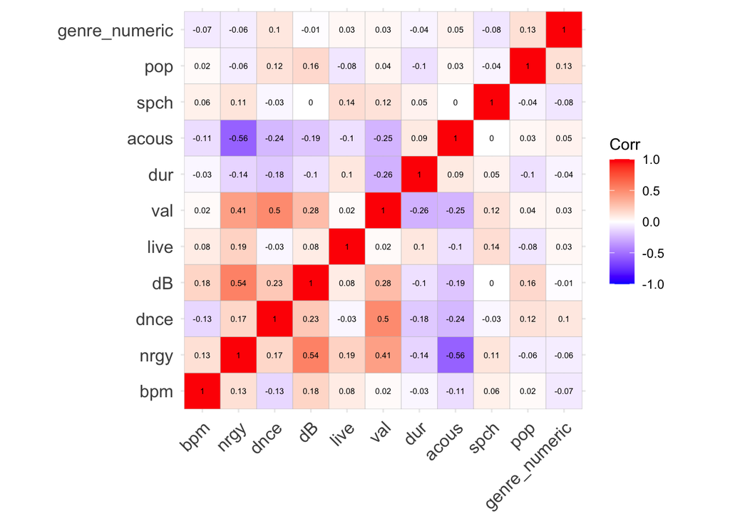

```r
suppressPackageStartupMessages(library(ggcorrplot))

m <- cor(data[,c(6:16) ])

ggcorrplot(m, lab = TRUE, lab_size = 2,ggtheme = ggplot2::theme_minimal(),
           method = "square", colors = c("blue", "white", "red"))
```

```r
suppressPackageStartupMessages(library(dplyr))
library(ggplot2)

dance_pop_data <- data %>%
  filter(genre == "dance pop")

head(dance_pop_data)
```

```
##   V1                                     title      artist     genre year bpm
## 1  3                                   TiK ToK       Kesha dance pop 2010 120
## 2  4                               Bad Romance   Lady Gaga dance pop 2010 119
## 3  7                                  Dynamite   Taio Cruz dance pop 2010 120
## 4  8                                   Secrets OneRepublic dance pop 2010 148
## 5 11 Club Can't Handle Me (feat. David Guetta)    Flo Rida dance pop 2010 128
## 6 13               Cooler Than Me - Single Mix Mike Posner dance pop 2010 130
##   nrgy dnce dB live val dur acous spch pop genre_numeric
## 1   84   76 -3   29  71 200    10   14  80            26
## 2   92   70 -4    8  71 295     0    4  79            26
## 3   78   75 -4    4  82 203     0    9  77            26
## 4   76   52 -6   12  38 225     7    4  77            26
## 5   87   62 -4    6  47 235     3    3  73            26
## 6   82   77 -5   70  63 213    18    5  73            26
```

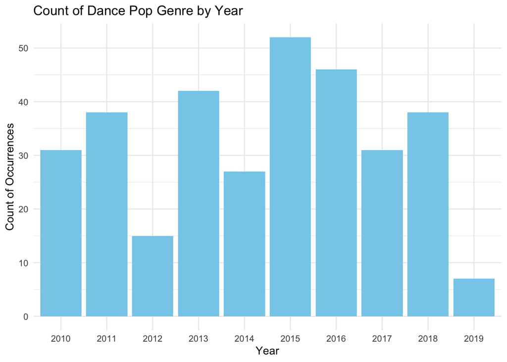

```r
ggplot(dance_pop_data, aes(x = as.factor(year))) +
  geom_bar(fill = "skyblue") +
  labs(title = "Count of Dance Pop Genre by Year", x = "Year", y = "Count of Occurrences") +
  theme_minimal()
```

```r
genre_year_count <- data %>%
  group_by(year, genre) %>%
  summarise(count = n(), .groups = 'keep')

head(genre_year_count)
```

```
## # A tibble: 6 × 3
## # Groups:   year, genre [6]
##    year genre          count
##   <int> <chr>          <int>
## 1  2010 art pop            1
## 2  2010 atl hip hop        3
## 3  2010 australian pop     2
## 4  2010 barbadian pop      2
## 5  2010 big room           1
## 6  2010 canadian pop       1
```

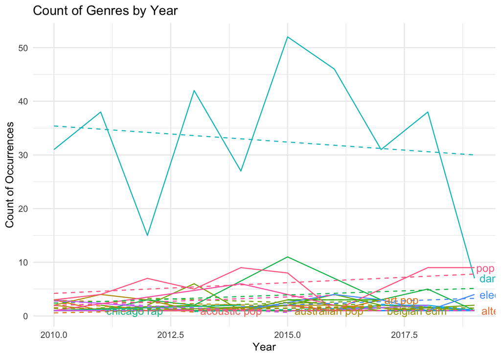

```r
options(repr.plot.width = 18, repr.plot.height = 8)


last_data_points <- genre_year_count %>%
  group_by(genre) %>%
  slice_max(year, n = 1)

ggplot(genre_year_count, aes(x = year, y = count, color = genre, group = genre)) +
  geom_line() +
  geom_smooth(method = "lm", se = FALSE, aes(color = genre),linewidth = 0.5, linetype = "dashed") +
  geom_text(data = last_data_points,
            aes(label = genre),
            hjust = -0.1,
            vjust = 0.5,
            check_overlap = TRUE)+
  labs(title = "Count of Genres by Year", x = "Year", y = "Count of Occurrences") +
  theme_minimal() +
  theme(legend.position = "none",
        legend.justification = "center")
```

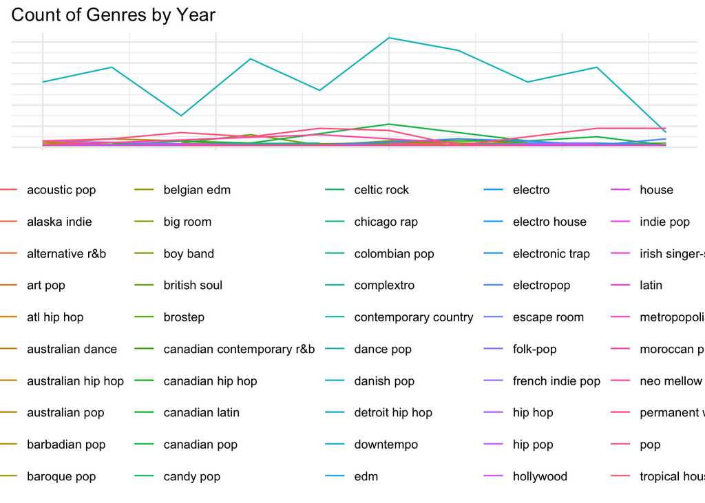

```r
ggplot(genre_year_count, aes(x = year, y = count, color = genre, group = genre)) +
  geom_line() +
  labs(title = "Count of Genres by Year", x = "Year", y = "Count of Occurrences") +
  theme_minimal() +
  theme(legend.position = "bottom",
        axis.title.x = element_blank(),
        axis.title.y = element_blank(),
        axis.text = element_blank(),
        axis.ticks = element_blank())
```

### Conclusion

Factors that have an impact on the popularity or a positive correlation are danceability, loudness and genre. This analysis mainly focused on the genre which is usually more within an artist’s control.

Dance Pop was the most popular genre from 2010 through 2018 before the popularity goes down towards 2019. The sharp decline in Dance Pop songs on the bill board 100 list represents a large change in interest in the music market and we would not recommend new artists to jump into that genre.

Pop music is trending upwards and would be a good recommendation for an artist looking to jump on to a positive trend. A few of the genres with smaller frequencies on the bill boards list are also trending upwards. It would be worth while to investigate which particular artists are trending and how they are reaching their audiences to create a shift in the music market.